# Modeling and prediction for movies

## Setup

### Load packages

```r
library(ggplot2)
library(dplyr)
library(statsr)
library(ggthemr)
ggthemr('fresh')
```

### Load data

```r
load("movies.Rdata")
```

## Part 1: Data

The data set is comprised of 651 randomly sampled movies produced and released before 2016.

It includes information from Rotten Tomatoes and IMDB about those movies.

We cannot infer causality from such data set because it’s an observed data , treatment isn’t randomly assigned so we can only make correlation conclusions. * * *

## Part 2: Research question

What are the factors responsible for increasing/decreasing the IMDB rate for a certain movie ?

this question and it’s findings may help movie creators to know the secret recepie for making high rated movie.

## Part 3: Exploratory data analysis

Let’s check the types of movies we have in our data set.

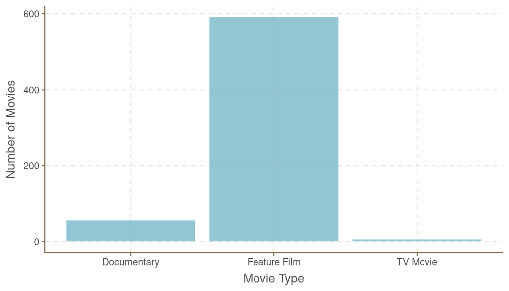

```r
movies %>% ggplot(aes(x=title_type)) + geom_bar(alpha=0.7) + labs(x="Movie Type", y= "Number of Movies")
```

As we can see from above that most of the movies are featured films.

Let’s see the distribution of runtime for each movie type

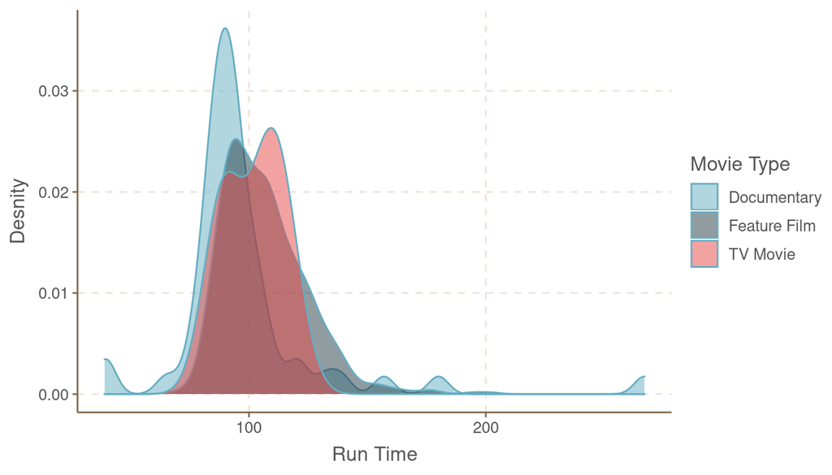

```r
movies %>% ggplot(aes(x=runtime,fill=title_type)) + geom_density(alpha=0.5) + labs(x="Run Time", y= "Desnity",fill="Movie Type")
```

```r
movies %>% group_by(title_type) %>% summarise(mean_run_time=mean(runtime,na.rm = TRUE))
```

```
## # A tibble: 3 x 2
##   title_type   mean_run_time
##   <fct>                <dbl>
## 1 Documentary           97.7
## 2 Feature Film         107.
## 3 TV Movie             102.
```

We can see that the Documentary movies are normally distributed but with more outliers on the right and mean around 97.7 minutes. Feature films are right skewed with mean around 107 minutes. TV Movies follows more of a bimodal distribution with mean around 102 minutes.

So let’s check the distibution of IMDB Ratings

```r
mean_ratings = mean(movies$imdb_rating)
mean_ratings
```

```
## [1] 6.493088
```

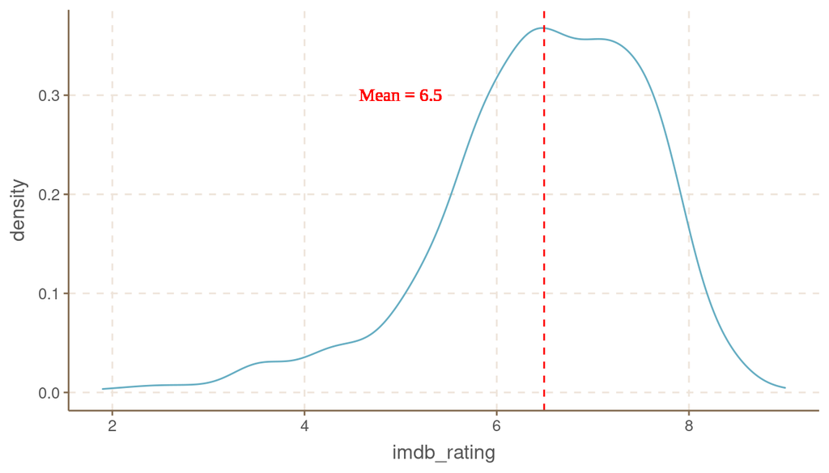

```r
movies %>% ggplot(aes(x=imdb_rating)) + geom_density() +
  geom_vline(xintercept =mean_ratings,color="red",linetype="dashed") + geom_text(x=5,y=0.3,label="Mean = 6.5",color="red",family = "Times New Roman")
```

We can see above the rating distribution is left skewed with mean around 6.5.

Let’s see the distribution of rating according to movie genre

```r
by_genre <- movies %>% group_by(genre)
rating_by_genre <- by_genre %>% summarise(mean_imdb_rating = mean(imdb_rating))
```

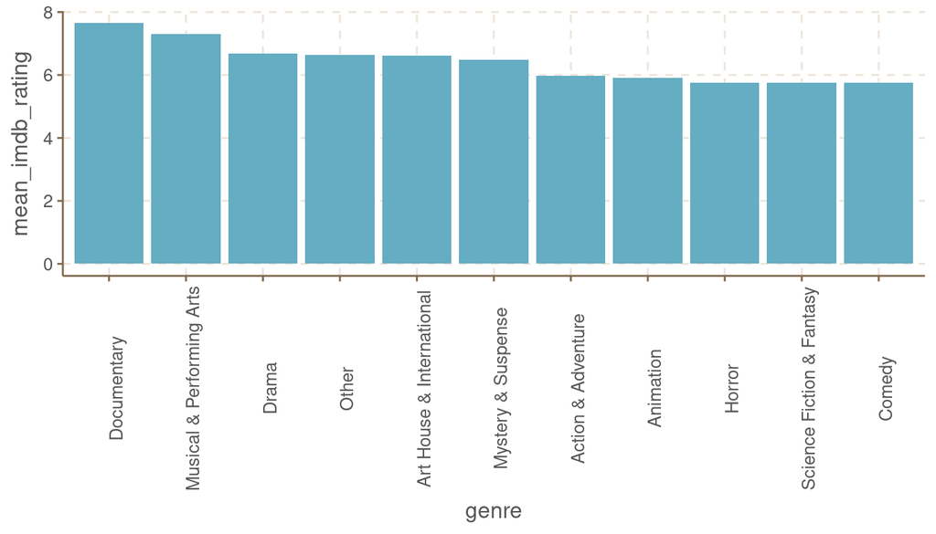

```r
rating_by_genre <- arrange(rating_by_genre,desc(mean_imdb_rating))
rating_by_genre$genre <- factor(rating_by_genre$genre, levels = rating_by_genre$genre)
rating_by_genre %>% ggplot(aes(x=genre,y= mean_imdb_rating)) + geom_bar(stat ="identity") + theme(axis.text.x = element_text(angle = 90))
```

We can see from above that Documentaries has the highest ratings , followed by Musical and Preforming arts and then Drama . * * *

## Part 4: Modeling

```r
model_1_all <- lm(data = movies,imdb_rating ~ title_type + genre + runtime + mpaa_rating + thtr_rel_month + best_pic_nom + best_pic_win + best_actor_win + best_actress_win + best_dir_win + top200_box + director +actor1 + actor2 + actor3 + actor4 + actor5)

summary(model_1_all)[4]
```

```
## $coefficients
##                                          Estimate   Std. Error       t value
## (Intercept)                          -7.106451613 6.209400e-14 -1.144467e+14
## title_typeFeature Film               -3.258064516 3.513914e-14 -9.271897e+13
## title_typeTV Movie                    3.080645161 1.864069e-14  1.652646e+14
## genreAnimation                       -2.903225806 3.096159e-14 -9.376862e+13
## genreArt House & International       -0.154838710 2.641315e-14 -5.862184e+12
## genreComedy                           1.619354839 2.544946e-14  6.363023e+13
## genreDocumentary                     -2.722580645 1.960562e-14 -1.388673e+14
## genreDrama                            1.619354839 2.479384e-14  6.531278e+13
## genreHorror                          -2.009677419 2.327711e-14 -8.633709e+13
## genreMusical & Performing Arts        3.438709677 2.132627e-14  1.612429e+14
## genreMystery & Suspense               1.458064516 2.275133e-14  6.408700e+13
## genreOther                            9.545161290 8.062205e-14  1.183939e+14
## genreScience Fiction & Fantasy        0.883870968 2.460863e-14  3.591711e+13
## runtime                               0.061290323 3.705118e-16  1.654207e+14
## mpaa_ratingNC-17                     11.267741935 2.884638e-14  3.906120e+14
## mpaa_ratingPG                         5.867741935 2.169103e-14  2.705147e+14
## mpaa_ratingPG-13                      5.854838710 2.293559e-14  2.552731e+14
## mpaa_ratingR                          3.138709677 3.424399e-14  9.165723e+13
## mpaa_ratingUnrated                    9.993548387 3.599180e-14  2.776618e+14
## thtr_rel_month                       -0.067741935 1.488176e-15 -4.552012e+13
## best_pic_nomyes                      -7.812903226 5.992487e-14 -1.303783e+14
## best_pic_winyes                       7.487096774 5.808168e-14  1.289063e+14
## best_actor_winyes                    -2.941935484 1.556218e-14 -1.890439e+14
## best_actress_winyes                  -1.687096774 2.194143e-14 -7.689094e+13
## best_dir_winyes                       7.561290323 1.805385e-14  4.188188e+14
## top200_boxyes                        -2.254838710 2.415340e-14 -9.335493e+13
## directorAbel Ferrara                  6.883870968 1.963450e-14  3.506008e+14
## directorAdam McKay                    2.709677419 1.057203e-14  2.563062e+14
## directorAdam Salky                    6.612903226 1.939796e-14  3.409071e+14
## directorAdam Shankman                 0.590322581 3.970619e-14  1.486727e+13
## directorAdam Simon                    7.887096774 5.441562e-14  1.449418e+14
## directorAdrian Grenier                2.287096774 1.325346e-14  1.725660e+14
## directorAgnes Varda                   2.680645161 1.556620e-14  1.722093e+14
## directorAgnieszka Holland            11.745161290 1.811598e-14  6.483316e+14
## directorAlan Alda                     2.419354839 1.180856e-14  2.048814e+14
## directorAlejandro Agresti             6.058064516 2.231939e-14  2.714261e+14
## directorAlejandro Gonzalez Inarritu  -2.103225806 2.262768e-14 -9.294923e+13
## directorAlejandro Jodorowsky          6.174193548 2.381325e-14  2.592756e+14
```

[output cut: 1214 more lines]

```
## actor1Michael Keaton                4.626351e-15
## actor1Nancy Allen                   6.027284e-15
## actor1Nicolas Cage                  2.332847e-13
## actor1Owen Wilson                   2.303236e-14
## actor1Paul Newman                   2.728949e-15
## actor1Peter Weller                  2.749751e-15
## actor1Ralph Fiennes                 6.737785e-15
## actor1Richard Gere                  4.584705e-15
## actor1River Phoenix                 5.955765e-14
## actor1Robert De Niro                3.018841e-15
## actor1Ryan Gosling                  3.564720e-14
## actor1Sam Rockwell                  3.314205e-15
## actor1Sean Penn                     1.649765e-15
## actor1Ted Danson                    6.557267e-15
## actor1Tommy Lee Jones               2.198355e-14
```

Let’s first check the number of Nan in director column.

```r
sum(is.na(movies$director))
```

```
## [1] 2
```

We can see that only two movies in our data set are missing names of their directors.

Let’s check NaNs in actor1 to actor5

```r
sum(is.na(movies$actor1)) + sum(is.na(movies$actor2)) +sum(is.na(movies$actor3)) +
  sum(is.na(movies$actor4)) + sum(is.na(movies$actor5))
```

```
## [1] 46
```

We can encode the new oscars_actors columns now .

```r
oscars_actors <- as.numeric(!is.na(movies$actor1)) + as.numeric(!is.na(movies$actor2)) + as.numeric(!is.na(movies$actor3)) + as.numeric(!is.na(movies$actor4)) + as.numeric(!is.na(movies$actor5))

movies$oscars_actors <- oscars_actors
```

Let’s check the directors column.

```r
length(unique(movies$director))
```

```
## [1] 533
```

We can see from above that we have 533 unique director.

Let’s check the NANs in this column.

```r
sum(is.na(movies$director))
```

```
## [1] 2
```

So let’s try and fit another model without the director column and see the difference before adding our engineered features.

```r
model_2_no_director <- lm(data = movies,imdb_rating ~ title_type + genre + runtime + mpaa_rating + thtr_rel_month + best_pic_nom + best_pic_win + best_actor_win + best_actress_win + best_dir_win + top200_box  +actor1 + actor2 + actor3 + actor4 + actor5)

summary(model_2_no_director)[4]
```

```
## $coefficients
##                                        Estimate   Std. Error       t value
## (Intercept)                        9.100000e+00 2.891317e-13  3.147354e+13
## title_typeFeature Film            -8.933333e+00 2.943469e-13 -3.034968e+13
## title_typeTV Movie                -1.300000e+01 1.284154e-13 -1.012339e+14
## genreAnimation                     3.733333e+00 9.354771e-14  3.990833e+13
## genreArt House & International     1.000000e+00 8.673684e-14  1.152913e+13
## genreComedy                        1.333333e-01 9.350773e-15  1.425907e+13
## genreDocumentary                  -1.046667e+01 3.245004e-13 -3.225471e+13
## genreDrama                         1.600000e+00 5.112151e-14  3.129798e+13
## genreHorror                        3.033333e+00 4.049370e-14  7.490877e+13
## genreMusical & Performing Arts    -6.000000e+00 2.200106e-13 -2.727141e+13
## genreMystery & Suspense           -1.566667e+00 7.719883e-14 -2.029392e+13
## genreOther                         1.733333e+00 1.328717e-14  1.304516e+14
## genreScience Fiction & Fantasy     1.400000e+00 1.365088e-14  1.025575e+14
## runtime                            3.333333e-02 8.826788e-16  3.776383e+13
## mpaa_ratingNC-17                   2.833333e+00 6.106501e-14  4.639864e+13
## mpaa_ratingPG                     -3.333333e-02 4.228736e-14 -7.882576e+11
## mpaa_ratingPG-13                   5.000000e-01 2.881071e-14  1.735466e+13
## mpaa_ratingR                       1.733333e+00 2.129754e-14  8.138654e+13
## mpaa_ratingUnrated                 3.000000e+00 5.408578e-14  5.546745e+13
## thtr_rel_month                     1.000000e-01 5.093600e-15  1.963248e+13
## best_pic_nomyes                    1.666667e+00 2.651161e-14  6.286555e+13
## best_pic_winyes                    3.333333e-02 4.320260e-14  7.715586e+11
## best_actor_winyes                 -1.933333e+00 1.694421e-14 -1.140999e+14
## best_actress_winyes                1.600000e+00 3.224739e-14  4.961642e+13
## best_dir_winyes                    1.266667e+00 5.444991e-14  2.326297e+13
## top200_boxyes                     -4.133333e+00 7.177975e-14 -5.758355e+13
## actor1Aaron Stanford               3.333333e-01 1.399818e-14  2.381261e+13
## actor1Aaron Taylor-Johnson         2.800000e+00 1.597624e-14  1.752602e+14
## actor1Adam Garcia                 -1.466667e+00 2.993309e-15 -4.899816e+14
## actor1Adam Sandler                 2.933333e+00 4.873414e-14  6.019052e+13
## actor1Adrienne Shelly              4.000000e-01 1.564360e-14  2.556956e+13
## actor1Aidan Quinn                  1.433333e+00 5.948823e-14  2.409440e+13
## actor1Al Pacino                   -1.900000e+00 3.856736e-14 -4.926446e+13
## actor1Alan Alda                    1.400000e+00 1.056804e-13  1.324749e+13
## actor1Alan Cumming                -4.666667e-01 8.760337e-15 -5.327040e+13
## actor1Alberto Mora                 3.166667e+00 1.256596e-13  2.520036e+13
## actor1Alexa Vega                   1.366667e+00 8.060808e-14  1.695446e+13
## actor1Alicia Silverstone          -1.333333e-01 3.205959e-14 -4.158921e+12
```

[output cut: 1218 more lines]

```
## actor2Mira Sorvino                2.871188e-14
## actor2Miranda July                1.178761e-14
## actor2Mireille Enos               1.896141e-14
## actor2Morgan Freeman              1.569100e-14
## actor2Naomi Watts                 4.946012e-15
## actor2Nastassja Kinski            1.104267e-14
## actor2Natalie Wood                5.880836e-15
## actor2Nick Stahl                  3.469286e-14
## actor2Omar Sharif                 1.681936e-14
## actor2Patrick Swayze              2.363384e-14
## actor2Patton Oswalt               2.385725e-14
## actor2Paul Bettany                1.494275e-14
## actor2Rae Dawn Chong              1.148967e-15
## actor2Richard Gere                2.574887e-14
## actor2Sam Shepard                 2.225201e-14
```

Now let’s add our new feautre.

```r
model_featured_1 <- lm(data = movies,imdb_rating ~ title_type + genre + runtime + mpaa_rating + thtr_rel_month + best_pic_nom + best_pic_win + best_actor_win + best_actress_win + best_dir_win + top200_box + oscars_actors)

summary(model_featured_1)[4]
```

```
## $coefficients
##                                    Estimate  Std. Error     t value
## (Intercept)                     6.351136491 0.570548359 11.13163573
## title_typeFeature Film         -0.783838831 0.333466021 -2.35058082
## title_typeTV Movie             -1.373828755 0.524694744 -2.61833908
## genreAnimation                 -0.203814442 0.352951356 -0.57745760
## genreArt House & International  0.636827824 0.271975315  2.34149127
## genreComedy                    -0.079585299 0.151108045 -0.52667811
## genreDocumentary                0.906443978 0.358790622  2.52638705
## genreDrama                      0.613742398 0.128609472  4.77213994
## genreHorror                    -0.119539994 0.224465024 -0.53255510
## genreMusical & Performing Arts  0.947893055 0.305363017  3.10415146
## genreMystery & Suspense         0.409164882 0.168600449  2.42683151
## genreOther                      0.508429907 0.255820490  1.98744795
## genreScience Fiction & Fantasy -0.292889386 0.320293648 -0.91444020
## runtime                         0.010830119 0.002214823  4.88983602
## mpaa_ratingNC-17               -0.340368463 0.682729911 -0.49854043
## mpaa_ratingPG                  -0.597160652 0.248015215 -2.40775814
## mpaa_ratingPG-13               -0.827883064 0.253834332 -3.26150942
## mpaa_ratingR                   -0.500062802 0.246731704 -2.02674725
## mpaa_ratingUnrated             -0.368848377 0.284048263 -1.29854121
## thtr_rel_month                 -0.001333818 0.010405015 -0.12818989
## best_pic_nomyes                 0.888128321 0.232936639  3.81274636
## best_pic_winyes                -0.061947282 0.410967346 -0.15073529
## best_actor_winyes              -0.044964109 0.107350938 -0.41885157
## best_actress_winyes             0.002276844 0.118668219  0.01918664
## best_dir_winyes                 0.357411967 0.154460374  2.31393954
## top200_boxyes                   0.576104218 0.243856904  2.36246835
## oscars_actors                  -0.038906474 0.081515203 -0.47729101
##                                    Pr(>|t|)
## (Intercept)                    2.241458e-26
## title_typeFeature Film         1.905497e-02
## title_typeTV Movie             9.050735e-03
## genreAnimation                 5.638390e-01
## genreArt House & International 1.952110e-02
## genreComedy                    5.986046e-01
## genreDocumentary               1.177081e-02
## genreDrama                     2.273229e-06
## genreHorror                    5.945315e-01
## genreMusical & Performing Arts 1.994775e-03
## genreMystery & Suspense        1.551391e-02
## genreOther                     4.731018e-02
## genreScience Fiction & Fantasy 3.608394e-01
## runtime                        1.285827e-06
## mpaa_ratingNC-17               6.182791e-01
## mpaa_ratingPG                  1.634043e-02
## mpaa_ratingPG-13               1.168690e-03
## mpaa_ratingR                   4.311369e-02
## mpaa_ratingUnrated             1.945819e-01
## thtr_rel_month                 8.980401e-01
## best_pic_nomyes                1.510945e-04
## best_pic_winyes                8.802333e-01
## best_actor_winyes              6.754690e-01
## best_actress_winyes            9.846984e-01
## best_dir_winyes                2.099552e-02
## top200_boxyes                  1.846011e-02
## oscars_actors                  6.333223e-01
```

We can see from above that our engineered feature didn’t capture as much as the removed features of actor1 to actor5 ,

We will remove them from our next model , but first let’s check how many unique actors we’ve in the data set.

```r
length(unique(c(movies$actor1,movies$actor2,movies$actor3,movies$actor4,movies$actor5)))
```

```
## [1] 2363
```

We can see from above the we have 2363 different actors, but do really knowing all the five main actors is a must?

Let’s build a model with only the first two main characters.

```r
model_3_actors_2 <- lm(data = movies,imdb_rating ~ title_type + genre + runtime + mpaa_rating + thtr_rel_month + best_pic_nom + best_pic_win + best_actor_win + best_actress_win + best_dir_win + top200_box  +actor1 + actor2 )

summary(model_3_actors_2)[4]
```

```
## $coefficients
##                                        Estimate   Std. Error       t value
## (Intercept)                        9.100000e+00 7.341236e-14  1.239573e+14
## title_typeFeature Film            -8.933333e+00 7.473651e-14 -1.195310e+14
## title_typeTV Movie                -1.300000e+01 3.260548e-14 -3.987060e+14
## genreAnimation                     3.733333e+00 2.375235e-14  1.571774e+14
## genreArt House & International     1.000000e+00 2.202302e-14  4.540702e+13
## genreComedy                        1.333333e-01 2.374220e-15  5.615880e+13
## genreDocumentary                  -1.046667e+01 8.239268e-14 -1.270339e+14
## genreDrama                         1.600000e+00 1.298007e-14  1.232659e+14
## genreHorror                        3.033333e+00 1.028160e-14  2.950253e+14
## genreMusical & Performing Arts    -6.000000e+00 5.586208e-14 -1.074074e+14
## genreMystery & Suspense           -1.566667e+00 1.960127e-14 -7.992681e+13
## genreOther                         1.733333e+00 3.373697e-15  5.137786e+14
## genreScience Fiction & Fantasy     1.400000e+00 3.466043e-15  4.039188e+14
## runtime                            3.333333e-02 2.241177e-16  1.487314e+14
## mpaa_ratingNC-17                   2.833333e+00 1.550479e-14  1.827392e+14
## mpaa_ratingPG                     -3.333333e-02 1.073703e-14 -3.104522e+12
## mpaa_ratingPG-13                   5.000000e-01 7.315219e-15  6.835065e+13
## mpaa_ratingR                       1.733333e+00 5.407579e-15  3.205378e+14
## mpaa_ratingUnrated                 3.000000e+00 1.373272e-14  2.184564e+14
## thtr_rel_month                     1.000000e-01 1.293297e-15  7.732177e+13
## best_pic_nomyes                    1.666667e+00 6.731463e-15  2.475935e+14
## best_pic_winyes                    3.333333e-02 1.096941e-14  3.038754e+12
## best_actor_winyes                 -1.933333e+00 4.302242e-15 -4.493781e+14
## best_actress_winyes                1.600000e+00 8.187813e-15  1.954124e+14
## best_dir_winyes                    1.266667e+00 1.382517e-14  9.162032e+13
## top200_boxyes                     -4.133333e+00 1.822533e-14 -2.267906e+14
## actor1Aaron Stanford               3.333333e-01 3.554226e-15  9.378506e+13
## actor1Aaron Taylor-Johnson         2.800000e+00 4.056468e-15  6.902557e+14
## actor1Adam Garcia                 -1.466667e+00 7.600200e-16 -1.929774e+15
## actor1Adam Sandler                 2.933333e+00 1.237390e-14  2.370580e+14
## actor1Adrienne Shelly              4.000000e-01 3.972008e-15  1.007047e+14
## actor1Aidan Quinn                  1.433333e+00 1.510443e-14  9.489488e+13
## actor1Al Pacino                   -1.900000e+00 9.792493e-15 -1.940262e+14
## actor1Alan Alda                    1.400000e+00 2.683291e-14  5.217474e+13
## actor1Alan Cumming                -4.666667e-01 2.224304e-15 -2.098034e+14
## actor1Alberto Mora                 3.166667e+00 3.190575e-14  9.925066e+13
## actor1Alexa Vega                   1.366667e+00 2.046689e-14  6.677450e+13
## actor1Alicia Silverstone          -1.333333e-01 8.140131e-15 -1.637975e+13
```

[output cut: 1234 more lines]

```
## actor2Mira Sorvino                7.290125e-15
## actor2Miranda July                2.992948e-15
## actor2Mireille Enos               4.814419e-15
## actor2Morgan Freeman              3.984043e-15
## actor2Naomi Watts                 1.255823e-15
## actor2Nastassja Kinski            2.803803e-15
## actor2Natalie Wood                1.493181e-15
## actor2Nick Stahl                  8.808733e-15
## actor2Omar Sharif                 4.270539e-15
## actor2Patrick Swayze              6.000780e-15
## actor2Patton Oswalt               6.057506e-15
## actor2Paul Bettany                3.794058e-15
## actor2Rae Dawn Chong              2.917299e-16
## actor2Richard Gere                6.537798e-15
## actor2Sam Shepard                 5.649925e-15
```

```r
model_4 <-lm(data = movies,imdb_rating ~ title_type + genre + runtime + best_dir_win +actor1 )

summary(model_4)
```

```
##
## Call:
## lm(formula = imdb_rating ~ title_type + genre + runtime + best_dir_win +
##     actor1, data = movies)
##
## Residuals:
##    Min     1Q Median     3Q    Max
## -2.953  0.000  0.000  0.000  1.792
##
## Coefficients: (2 not defined because of singularities)
##                                    Estimate Std. Error t value Pr(>|t|)
## (Intercept)                       5.0757224  1.0271958   4.941 2.03e-06 ***
## title_typeFeature Film            0.0521830  1.2381633   0.042 0.966438
## title_typeTV Movie               -0.1475327  1.2411004  -0.119 0.905533
## genreAnimation                   -0.0516610  0.8821422  -0.059 0.953377
## genreArt House & International    0.6098266  0.6602914   0.924 0.357173
## genreComedy                       0.1467901  0.2570438   0.571 0.568795
## genreDocumentary                  1.1171960  1.4493210   0.771 0.441998
## genreDrama                        0.6807053  0.2265952   3.004 0.003116 **
## genreHorror                      -0.3841694  0.6692987  -0.574 0.566824
## genreMusical & Performing Arts    1.0407884  0.5429686   1.917 0.057133 .
## genreMystery & Suspense           0.5554321  0.2638621   2.105 0.036935 *
## genreOther                        1.1832540  0.4146057   2.854 0.004921 **
## genreScience Fiction & Fantasy    1.5936320  0.7322215   2.176 0.031067 *
## runtime                           0.0153737  0.0044663   3.442 0.000746 ***
## best_dir_winyes                   0.0454727  0.2355269   0.193 0.847163
## actor1Aaron Stanford             -0.5598687  1.2986716  -0.431 0.667000
## actor1Aaron Taylor-Johnson       -0.5928475  1.0069474  -0.589 0.556898
## actor1Adam Garcia                -1.0691105  1.1357153  -0.941 0.348017
## actor1Adam Sandler               -1.4813874  1.0069267  -1.471 0.143305
## actor1Adrienne Shelly             0.3077579  1.1349686   0.271 0.786636
## actor1Aidan Quinn                -0.7076158  1.1350829  -0.623 0.533953
## actor1Al Pacino                  -0.7368651  0.9107641  -0.809 0.419744
## actor1Alan Alda                  -1.4558897  0.9940387  -1.465 0.145090
## actor1Alan Cumming                0.1847685  1.1363738   0.163 0.871053
## actor1Alberto Mora                0.6079344  1.3734739   0.443 0.658666
## actor1Alexa Vega                 -1.3429532  1.1552381  -1.162 0.246858
## actor1Alicia Silverstone         -2.8669688  1.1507243  -2.491 0.013796 *
## actor1Aline Kominsky              0.9480194  1.2630903   0.751 0.454081
## actor1Alwy Visschedyk            -0.2380445  1.3708720  -0.174 0.862376
```

[output cut: 461 more lines]

```
## actor1Willie Nelson              -1.0947908  1.1909752  -0.919 0.359427
## actor1Winston Chao                0.1163063  1.1579749   0.100 0.920128
## actor1Woody Allen                 0.5215801  0.9548779   0.546 0.585711
## actor1Woody Harrelson            -1.6689683  1.1397042  -1.464 0.145153
## actor1Yarko                       0.6774713  1.3713632   0.494 0.622010
## actor1Zach Braff                 -1.0597687  0.9926942  -1.068 0.287408
## actor1Zach Galifianakis          -1.1537368  1.1355309  -1.016 0.311228
## actor1Zlatko Buric                0.1077579  1.1349686   0.095 0.924485
## ---
## Signif. codes:  0 '***' 0.001 '**' 0.01 '*' 0.05 '.' 0.1 ' ' 1
##
## Residual standard error: 0.8023 on 152 degrees of freedom
##   (3 observations deleted due to missingness)
## Multiple R-squared:  0.8715, Adjusted R-squared:  0.4528
## F-statistic: 2.082 on 495 and 152 DF,  p-value: 1.059e-07
```

## Part 5: Prediction

Now for the prediction task.

We will choose The Magnificent Seven, because it’s my 2016 favorite movie , also it’s not included in the data set, and we will try and predict it’s rating.

Movie available at : [The Magnificent Seven](https://www.imdb.com/title/tt2404435/?ref_=adv_li_tt)

Movie rate is = 6.9

actor1 -> “Denzel Washington”

actor2 -> “Ethan Hawke”

title_type -> “Feature Film”

genre -> “Action & Adventure”

runtime -> 132

best_dir_win -> yes " Antoine Fuqua"

```r
non_cul_animals <- data.frame("title_type" = "Feature Film" , "genre" = "Action & Adventure" ,  "runtime" = 132 , "best_dir_win"= "yes" , "actor1" = "Denzel Washington" , "actor2" = "Ethan Hawke" )
non_cul_animals
```

```
##     title_type              genre runtime best_dir_win            actor1
## 1 Feature Film Action & Adventure     132          yes Denzel Washington
##        actor2
## 1 Ethan Hawke
```

```r
k <- predict.lm(object = model_4,newdata = non_cul_animals,interval = "confidence")
k
```

```
##        fit      lwr      upr
## 1 6.853131 5.555125 8.151136
```

As we can see that the predicted rate is 6.85 and the true rate is 6.9 , with 95% confidence interval (5.555125,8.151136).

## Part 6: Conclusion

We couldn’t infer a causal statements from our research above , but we captured the relationship between some features in the movie and the rate it was given at IMDB , also we tested it for a random movie the dataset wasn’t trained on and it accurately predicted it’s rate, but the onlt draw back we have is our model needs to be fed more data to acuratly control for more actors in any given character.